# String Distance Comparisons

# 8. Conclusion + Recommendations

Important observations:  
1. While `jw`, `cos`, and `jac` algorithms tend to give matches more frequently (with a lower dscore as well), there is value in keeping `dl` and `qgram` as these are very helpful in catching false positives.  
2. The method of using a `max_dist` that depends on the ED tends to guard against false positives better than the base method of `max_dist = 5` (which increases the error rate).

Finally, to recap the types of results:

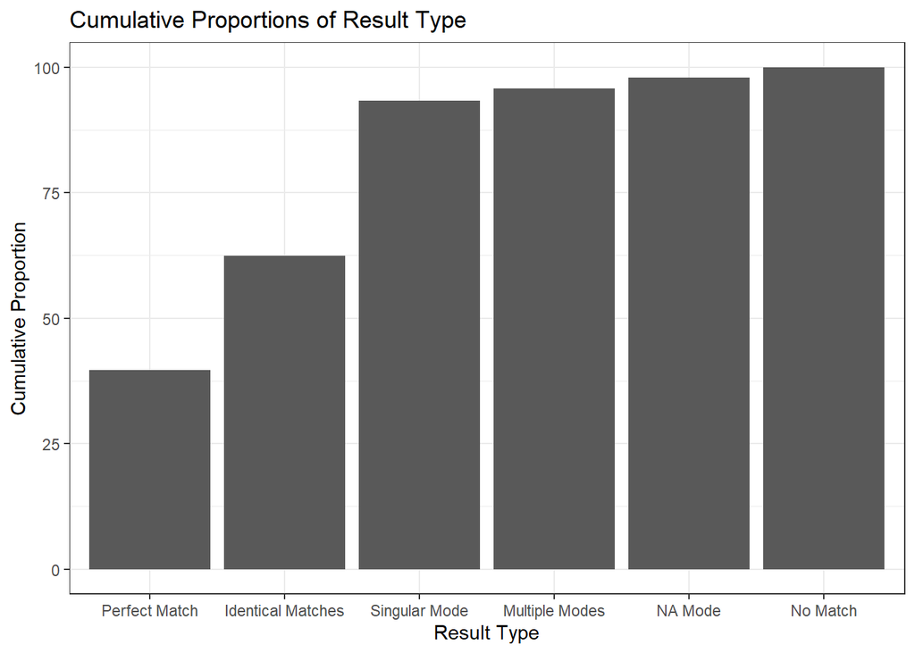

```r
result_freq <- match_dict_imp %>%
  transmute(result_type = factor(as.numeric(result_type), levels = 1:6,
                              labels = c("Perfect Match", "Identical Matches",
                                         "Singular Mode", "Multiple Modes",
                                         "NA Mode", "No Match"))) %>%
  group_by(result_type) %>%
  summarize(count = n(), perc = count / nrow(match_dict) * 100) %>%
  mutate(cumsum = cumsum(perc))

ggplot(result_freq, aes(x = result_type, y = cumsum)) +
  geom_bar(stat = "identity") +
  labs(title = "Cumulative Proportions of Result Type", x = "Result Type", y = "Cumulative Proportion") +
  theme_bw()
```

This EDA gives a good directive of the street matching workflow. The suggested workflow is:

[output not shown]

For fill down, the recommended step is take a lookaround of 3 streets in the top/bottom of the row in the same ED and match using jw. Records can then be manually cleaned.